# Homework 4: Machine Learning

## Algorithmic Bias

In May 2016, Jeff Larson and others from ProPublica published a story about [algorithmic bias in criminal justice risk assessment scores](https://www.propublica.org/article/machine-bias-risk-assessments-in-criminal-sentencing). These scores are used to inform decisions about who can be set free at every stage of the criminal justice system, from assigning bond amounts to even more fundamental decisions about defendants’ freedom. In Arizona, Colorado, Delaware, Kentucky, Louisiana, Oklahoma, Virginia, Washington and Wisconsin, the results of such assessments are given to judges during criminal sentencing.

In 2014, then U.S. Attorney General Eric Holder warned that the risk scores might be injecting bias into the courts. He called for the U.S. Sentencing Commission to study their use. “Although these measures were crafted with the best of intentions, I am concerned that they inadvertently undermine our efforts to ensure individualized and equal justice,” he said, adding, “they may exacerbate unwarranted and unjust disparities that are already far too common in our criminal justice system and in our society.” The sentencing commission did not, however, launch a study of risk scores. So ProPublica did, as part of a larger examination of the powerful, largely hidden effect of algorithms in American life.

ProPublica obtained the risk scores assigned to more than 7,000 people arrested in Broward County, Florida, in 2013 and 2014 and checked to see how many were charged with new crimes over the next two years. The score proved remarkably unreliable in forecasting violent crime. In addition, ProPublica was able to show the algorithm was racially biased.

ProPublica completed a thorough analysis involving logistic regression, survival analysis and other statistical methods ([check out more details here if interested](https://www.propublica.org/article/how-we-analyzed-the-compas-recidivism-algorithm/)), but for this assignment you will be exploring how the algorithm is biased and communicating this bias.

The data for ProPublica’s analysis is contained in the file `compas-scores-two-years.csv`. Below are the variables we will be using:

- `race`: Race of the individual
- `two_year_recid`: Did the individual reoffend (commit another crime) within 2 years?
- `decile_score`: Risk score, 1-10
- `score_text`: score group, “Low”: `decile_score` = 1-3, “Medium”: `decile_score` = 4-7, “High”: `decile_score` = 8-10

### Question 1

While there are several race/ethnicity categories represented in this dataset, we will limit our analyses to those who self-identified as Caucasian or African-American. Read in the data and filter the data frame to only include Caucasian and African-American individuals. How many African-American individuals are represented in this dataset and how many Caucasian individuals are represented?

**Solution**

- 5 points
- 2.5 for each value

```r
scores <- read_csv("compas-scores-two-years.csv")

races <- c("African-American", "Caucasian")
data <- scores %>% filter(race %in% races)

table(data$race)
```

```
##
## African-American        Caucasian
##             3696             2454
```

There are 3,696 African-Americans and 2,454 Caucasians.

### Question 2

Make 2 bar charts of `decile_score`, one for each race group. What do you notice about the distributions of scores for the two groups?

**Solution**

- 10 points
- +5 for the plots (2.5 each)
  - -1 for not having “pretty” labels
  - Don’t take off points if they didn’t use `facet_grid` but encourage them to if they didn’t
- +5 for the description
  - -2 if they tried but the descriptions don’t make sense

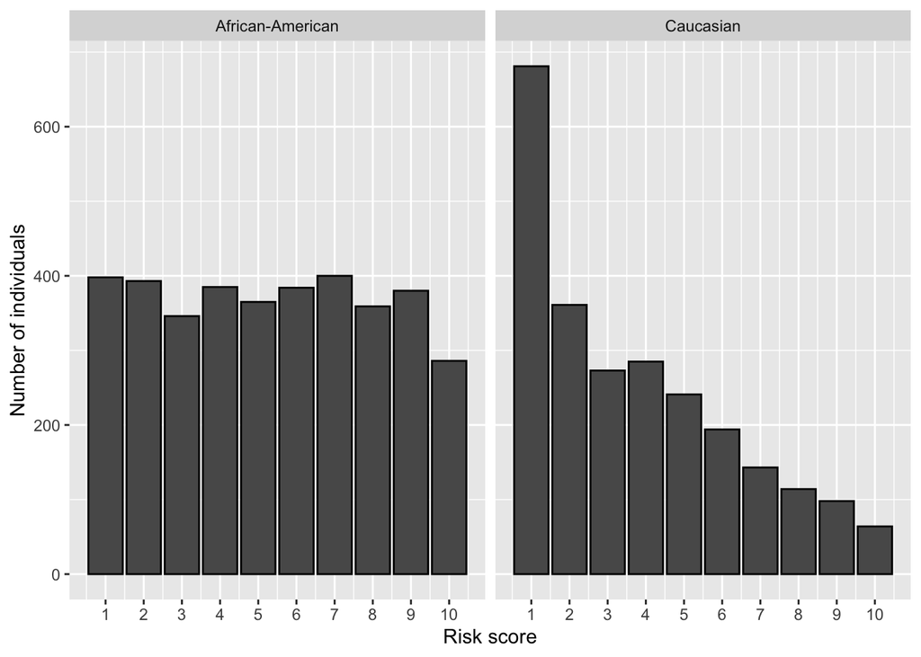

```r
data %>% ggplot(aes(decile_score)) +
  geom_bar(color = "black") +
    xlab("Risk score") +
    scale_x_continuous(breaks = seq(1,10)) +
    ylab("Number of individuals") +
  facet_grid(~race)
```

The scores are right-skewed for Caucasians and uniformly distributed for African-Americans. In other words, most Caucasians have lower risk scores (the number of individuals in each risk score decreases as score increases) while the number of African-Americans in each score group are about equal.

### Question 3

Is the risk score a good predictor of two-year recidivism (i.e., committing another crime within 2 years)? Create a new variable called `binary_score` that is equal to 0 if `score_text` is equal to “Low” (this will be the “low-risk” group) and 1 otherwise (this will be the “high-risk” group). Create a 2x2 table of `binary_score` and `two_year_recid` using the `table` function. Calculate accuracy, sensitivity, specificity, false positive rate and false negative rate by hand. (Note that you are not able to use the `confusionMatrix` function because you are not testing a model here.) What is the accuracy? Are the sensitivity and specificity balanced? Are the false positive rate and false negative rate balanced?

- Here, false positive rate is the number of false positives over the total number of true negatives, and false negative rate is the number of false negatives over the total number of true positives.

**Solution**

- 10 points
- +5 for each value (accuracy, sensitivity, specificity, FPR, FNR)
  - -1 if they switched the classes and called a TP the proportion of 0s correctly classified
- +2.5 for mentioning the sensitivity and specificity are balanced
- +2.5 for mentioning the FPR and FNR are balanced

```r
data <- data %>% mutate(binary_score = ifelse(score_text == "Low", 0, 1))
with(data, table(binary_score, two_year_recid))
```

```
##             two_year_recid
## binary_score    0    1
##            0 2129  993
##            1 1154 1874
```

```r
n = 1874 + 2129 + 993 + 1154
acc = (1874 + 2129)/n
TP = sum(data$binary_score == 1 & data$two_year_recid == 1)
FP = sum(data$binary_score == 1 & data$two_year_recid == 0)
TN = sum(data$binary_score == 0 & data$two_year_recid == 0)
FN = sum(data$binary_score == 0 & data$two_year_recid == 1)
sens = TP/(TP+FN)
spec = TN/(TN+FP)
FP_rate = FP/(FP+TN)
FN_rate = FN/(FN+TP)

results = data.frame("Accuracy" = acc,
                                         "Sensitivity" = sens,
                                         "Specificity" = spec,
                                         "FP_Rate" = FP_rate,
                                         "FN_Rate" = FN_rate)
results
```

```
##    Accuracy Sensitivity Specificity   FP_Rate   FN_Rate
## 1 0.6508943   0.6536449   0.6484922 0.3515078 0.3463551
```

### Question 4

- 15 points
- +10 for each value (accuracy, sensitivity, specificity, FPR, FNR) for each group
  - Don’t take off additional points if they switched the classes (see question 3 rubric above)
- +5 for the explanation
  - -2 if they tried but it doesn’t make sense. They don’t have to give specific percentages like I did - text is enough

Now calculate the overall accuracy, sensitivity, specificity, false positive rate and false negative rate for each race group. Again, calculate these values without using `confusionMatrix`. Does the algorithm perform better for one group over the other? Describe how the model is biased.

- Hint: think about what false positives, false negatives, false positive rate and false negative rate mean in this context.

**Solution**

```r
data %>% group_by(race) %>%
                 summarize(acc = sum(binary_score == two_year_recid)/n(),
                                    TP = sum(binary_score == 1 & two_year_recid == 1),
                                    FP = sum(binary_score == 1 & two_year_recid == 0),
                                    TN = sum(binary_score == 0 & two_year_recid == 0),
                                    FN = sum(binary_score == 0 & two_year_recid == 1),
                                    sens = TP/(TP+FN),
                                    spec = TN/(TN+FP),
                                    FP_rate = FP/(FP+TN),
                                    FN_rate = FN/(FN+TP))
```

```
## # A tibble: 2 x 10
##   race               acc    TP    FP    TN    FN  sens  spec FP_rate FN_rate
##   <chr>            <dbl> <int> <int> <int> <int> <dbl> <dbl>   <dbl>   <dbl>
## 1 African-American 0.638  1369   805   990   532 0.720 0.552   0.448   0.280
## 2 Caucasian        0.670   505   349  1139   461 0.523 0.765   0.235   0.477
```

These contingency tables reveal that the algorithm is more likely to misclassify an African-American defendant as higher risk than a Caucasian defendant. African-American defendants who do not recidivate were nearly twice as likely to be classified as higher risk compared to their Caucasian counterparts (45 percent vs. 23 percent).

The algorithm tended to make the opposite mistake with Caucasians, meaning that it was more likely to wrongly predict that Caucasian people would not commit additional crimes if released compared to African-American defendants. The algorithm under-classified Caucasian reoffenders as low risk 70.5 percent more often than African-American reoffenders (48 percent vs. 28 percent).

## Fetal Health

Reduction of child mortality is reflected in several of the United Nations’ Sustainable Development Goals and is a key indicator of human progress. The UN expects that countries aim to reduce under‑5 mortality to at least as low as 25 per 1,000 live births by 2030.

Parallel to the notion of child mortality is of course maternal mortality, which accounts for 295,000 deaths during and following pregnancy and childbirth (as of 2017). The vast majority of these deaths (94%) occurred in low-resource settings, and most could have been prevented.

Cardiotocograms (CTGs) are a simple and cost accessible option to assess fetal health, allowing health care professionals to take action in order to prevent child and maternal mortality. The equipment itself works by sending ultrasound pulses and reading its response, thus shedding light on fetal heart rate (FHR), fetal movements, uterine contractions and more.

We’ll be using a dataset that contains 2,126 records of features extracted from Cardiotocogram exams including the baseline fetal heart rate, uterine contractions, and fetal movement. For more details about the dataset, visit this [Kaggle page](https://www.kaggle.com/andrewmvd/fetal-health-classification). The outcome of interest is fetal health classification:

- 1: Normal
- 2: Suspect
- 3: Pathological

We will be using the features available in this dataset to classify fetal health.

Use the following code to read in the data and split it into training and test sets with 60% of the data in the training set and 40% in the test set. Here we use a new function, `stratified`, from the `splitstackshape` package to split the data because we have 3 classes that are not balanced, meaning the number of observations in each class is not equivalent. The `stratified` function samples the same percent of samples from each class - in this case, fetal class. Note: keep `set.seed(1)` so you get the same train/test split and model predictions we do.

```r
fetal <- read_csv("fetal_health.csv")

set.seed(1)

x <- stratified(fetal, "fetal_health", 0.6, keep.rownames = TRUE)
train_set <- x %>% dplyr::select(-rn)
train_index <- as.numeric(x$rn)
test_set <- fetal[-train_index,]
```

### Question 5

Fit a decision tree (classification tree) that predicts `fetal_health` using all other variables in the dataset. What is the overall accuracy of the model, and accuracy for each class? Is the accuracy balanced across classes? Hint: You may need to calculate the accuracy for each class by hand using the confusion matrix.

**Solution**

- 15 points
- +7 for the model
  - They aren’t expected to tune any hyperparameters, but if they did and got different answers for the performance metrics that’s fine and don’t take off points.
- +3 for calculating the accuracy for each class.
  - -1 if they tried but got incorrect values
- +5 for mentioning accuracy is not balanced across classes.

```r
tree_fit = tree(as.factor(fetal_health) ~ ., data = train_set)
tree_preds <- predict(tree_fit, newdata = test_set, type = "class")
confusionMatrix(table(pred = tree_preds, true = test_set$fetal_health))
```

```
## Confusion Matrix and Statistics
##
##     true
## pred   1   2   3
##    1 644  37   6
##    2   9  78   1
##    3   9   3  63
##
## Overall Statistics
##
##                Accuracy : 0.9235
##                  95% CI : (0.9036, 0.9405)
##     No Information Rate : 0.7788
##     P-Value [Acc > NIR] : < 2.2e-16
##
##                   Kappa : 0.7808
##
##  Mcnemar's Test P-Value : 0.000324
##
## Statistics by Class:
##
##                      Class: 1 Class: 2 Class: 3
## Sensitivity            0.9728  0.66102  0.90000
## Specificity            0.7713  0.98634  0.98462
## Pos Pred Value         0.9374  0.88636  0.84000
## Neg Pred Value         0.8896  0.94751  0.99097
## Prevalence             0.7788  0.13882  0.08235
## Detection Rate         0.7576  0.09176  0.07412
## Detection Prevalence   0.8082  0.10353  0.08824
## Balanced Accuracy      0.8720  0.82368  0.94231
```

```r
test_set <- test_set %>% mutate(tree_preds = tree_preds)
test_set %>% group_by(fetal_health) %>%
    summarize(acc = sum(fetal_health == tree_preds)/n())
```

```
## # A tibble: 3 x 2
##   fetal_health   acc
##          <dbl> <dbl>
## 1            1 0.973
## 2            2 0.661
## 3            3 0.9
```

Accuracy:

```r
temp <- test_set %>% mutate(pred1 = ifelse((tree_preds == 1 & fetal_health == 1)|(tree_preds != 1 & fetal_health != 1), 1, 0),
                                        pred2 = ifelse((tree_preds == 2 & fetal_health == 2)|(tree_preds != 2 & fetal_health != 2), 1, 0),
                                        pred3 = ifelse((tree_preds == 3 & fetal_health == 3)|(tree_preds != 3 & fetal_health != 3), 1, 0))

mean(temp$pred1)
```

```
## [1] 0.9282353
```

```r
mean(temp$pred2)
```

```
## [1] 0.9411765
```

```r
mean(temp$pred3)
```

```
## [1] 0.9776471
```

The overall accuracy of this model is 92.4%. The accuracy varies by fetal health category. The model is the best at predicting class 1 (“Normal”) with an accuracy of 97%. This may be due to class imbalance where most examples are of class 1. The model is second best at predicting class 3 (“Pathological”) with an accuracy of 90%. The model predicts class 2 with 66% accuracy. It seems like the model is much better at predicting the more extreme classes and not class 2, “Suspect”. This may point to sicker fetuses being much easier to detect compared to those not as sick.

### Question 6

Fit a random forest that predicts `fetal_health` using all other variables in the dataset. What is the overall accuracy of the model, and accuracy for each class? Is the accuracy balanced across classes? Hint: You may need to calculate the accuracy for each class by hand using the confusion matrix.

**Solution**

- 15 points
- +7 for the model
  - They aren’t expected to tune any hyperparameters, but if they did and got different answers for the performance metrics that’s fine and don’t take off points.
- +3 for calculating the accuracy for each class.
- +5 for mentioning accuracy is not balanced across classes.

```r
# Fit a regression tree using all of the available predictors
rf_fit = randomForest(as.factor(fetal_health) ~ ., data = train_set)

# Use tree for prediction
rf_preds <- predict(rf_fit, newdata = test_set, type = "class")
confusionMatrix(table(pred = rf_preds, true = test_set$fetal_health))
```

```
## Confusion Matrix and Statistics
##
##     true
## pred   1   2   3
##    1 651  25   6
##    2   8  91   7
##    3   3   2  57
##
## Overall Statistics
##
##                Accuracy : 0.94
##                  95% CI : (0.9219, 0.955)
##     No Information Rate : 0.7788
##     P-Value [Acc > NIR] : < 2.2e-16
##
##                   Kappa : 0.8294
##
##  Mcnemar's Test P-Value : 0.005757
##
## Statistics by Class:
##
##                      Class: 1 Class: 2 Class: 3
## Sensitivity            0.9834   0.7712  0.81429
## Specificity            0.8351   0.9795  0.99359
## Pos Pred Value         0.9545   0.8585  0.91935
## Neg Pred Value         0.9345   0.9637  0.98350
## Prevalence             0.7788   0.1388  0.08235
## Detection Rate         0.7659   0.1071  0.06706
## Detection Prevalence   0.8024   0.1247  0.07294
## Balanced Accuracy      0.9092   0.8753  0.90394
```

Sensitivity:

```r
test_set <- test_set %>% mutate(rf_preds = rf_preds)
test_set %>% group_by(fetal_health) %>%
    summarize(acc = sum(fetal_health == rf_preds)/n())
```

```
## # A tibble: 3 x 2
##   fetal_health   acc
##          <dbl> <dbl>
## 1            1 0.983
## 2            2 0.771
## 3            3 0.814
```

Accuracy:

```r
temp <- test_set %>% mutate(pred1 = ifelse((rf_preds == 1 & fetal_health == 1)|(rf_preds != 1 & fetal_health != 1), 1, 0),
                                        pred2 = ifelse((rf_preds == 2 & fetal_health == 2)|(rf_preds != 2 & fetal_health != 2), 1, 0),
                                        pred3 = ifelse((rf_preds == 3 & fetal_health == 3)|(rf_preds != 3 & fetal_health != 3), 1, 0))

mean(temp$pred1)
```

```
## [1] 0.9505882
```

```r
mean(temp$pred2)
```

```
## [1] 0.9505882
```

```r
mean(temp$pred3)
```

```
## [1] 0.9788235
```

The overall accuracy of the model is 94%. The accuracy again varies by fetal health category. The model is the best at predicting class 1 (“Normal”) with an accuracy of 98%. The model is second best at predicting class 3 (“Pathological”) with an accuracy of 81%. The model predicts class 2 with 77% accuracy. It seems like the model is much better at predicting class 1, the class with the most examples. This model does a better job at classifying “Suspect” fetuses than the decision tree above, but is worse at classifying “Pathological” fetuses.

### Question 7

Fit a kNN model with k = 4 that predicts `fetal_health` using all other variables in the dataset. What is the overall accuracy of the model, and accuracy for each class? Is the accuracy balanced across classes? Hint: You may need to calculate the accuracy for each class by hand using the confusion matrix.

**Solution**

- 15 points
- +7 for the model
  - -1 for not using the right `k`
  - They aren’t expected to tune any hyperparameters, but if they did and got different answers for the performance metrics that’s fine and don’t take off points.
- +3 for calculating the accuracy for each class.
- +5 for mentioning accuracy is not balanced across classes.

```r
knn_fit <- knn3(as.factor(fetal_health) ~ ., data = train_set, k = 4)

knn_preds <- predict(knn_fit, newdata = test_set, type = "class")
confusionMatrix(table(pred = knn_preds, true = test_set$fetal_health))
```

```
## Confusion Matrix and Statistics
##
##     true
## pred   1   2   3
##    1 636  44  11
##    2  22  71   8
##    3   4   3  51
##
## Overall Statistics
##
##                Accuracy : 0.8918
##                  95% CI : (0.8689, 0.9119)
##     No Information Rate : 0.7788
##     P-Value [Acc > NIR] : < 2e-16
##
##                   Kappa : 0.686
##
##  Mcnemar's Test P-Value : 0.00492
##
## Statistics by Class:
##
##                      Class: 1 Class: 2 Class: 3
## Sensitivity            0.9607  0.60169  0.72857
## Specificity            0.7074  0.95902  0.99103
## Pos Pred Value         0.9204  0.70297  0.87931
## Neg Pred Value         0.8365  0.93725  0.97601
## Prevalence             0.7788  0.13882  0.08235
## Detection Rate         0.7482  0.08353  0.06000
## Detection Prevalence   0.8129  0.11882  0.06824
## Balanced Accuracy      0.8341  0.78036  0.85980
```

Sensitivity:

```r
test_set <- test_set %>% mutate(knn_preds = knn_preds)
test_set %>% group_by(fetal_health) %>%
    summarize(acc = sum(fetal_health == knn_preds)/n())
```

```
## # A tibble: 3 x 2
##   fetal_health   acc
##          <dbl> <dbl>
## 1            1 0.961
## 2            2 0.602
## 3            3 0.729
```

Accuracy:

```r
temp <- test_set %>% mutate(pred1 = ifelse((knn_preds == 1 & fetal_health == 1)|(knn_preds != 1 & fetal_health != 1), 1, 0),
                                        pred2 = ifelse((knn_preds == 2 & fetal_health == 2)|(knn_preds != 2 & fetal_health != 2), 1, 0),
                                        pred3 = ifelse((knn_preds == 3 & fetal_health == 3)|(knn_preds != 3 & fetal_health != 3), 1, 0))

mean(temp$pred1)
```

```
## [1] 0.9047059
```

```r
mean(temp$pred2)
```

```
## [1] 0.9094118
```

```r
mean(temp$pred3)
```

```
## [1] 0.9694118
```

The overall accuracy of the model is 89.2% - the lowest of the 3 models. The accuracy again varies by fetal health category. The model is the best at predicting class 1 (“Normal”) with an accuracy of 96%. The model is second best at predicting class 3 (“Pathological”) with an accuracy of 73%. The model predicts class 2 with 60% accuracy. It seems like the model is much better at predicting class 1, the class with the most examples. This model performs worse for all classes compared to the two models above.

### Question 8

Of the models you fit in questions 5-7, which model would you choose as the best model for predicting fetal health category? Justify your answer. Be sure to include diagnostic metrics (for example, accuracy, sensitivity, specificity, AUROC, etc.) as part of your justification. You do not need to use all of these metrics - just be sure to mention at least 1 of them. Note there is no one right answer for this question. The point is to make you critically evaluate different models and make an informed choice in model.

**Solution**

- 15 points
- +5 for mentioning performance varies by model.
- +10 for justifying which model they would choose.
  - -2 if they choose the `knn` model

Sensitivity:

| Model | Overall Accuracy | Class 1 Sensitivity | Class 2 Sensitivity | Class 3 Sensitivity |
| --- | --- | --- | --- | --- |
| Decision Tree | 92.4% | 97% | 66% | 90% |
| Random Forest | 94% | 98% | 77% | 81% |
| kNN, k = 4 | 89.2% | 96% | 60% | 73% |

In terms of overall accuracy, the random forest model performs the best at 94%. And while this model is best at classifying “Normal” and “Suspect” fetuses, it is worse at classifying “Pathological” fetuses, with the decision tree performing the best for this class. The kNN model performs the worst overall and across classes compared to the other models and should not be chosen as the final model. It comes down to a judgment call between the decision tree and random forest. If it is better to identify fetuses in the most distress, the decision tree should be used. While the random forest model classifies more “Suspect” fetuses correctly, it misclassifies 13 “Pathological” fetuses as “Normal” or “Suspect”, compared to only 7 incorrect misclassifications by the decision tree. On the other hand, if classifying a “Normal” fetus as “Suspect” or “Pathological” is dangerous (i.e., the intervention can be dangerous to the fetus or mother), the random forest model should be chosen since it correctly classifies more “Normal” fetuses.

Choosing either the decision tree or random forest is best, depending on which class should have the most weight for accuracy.

| Model | Overall Accuracy | Class 1 Accuracy | Class 2 Accuracy | Class 3 Accuracy |
| --- | --- | --- | --- | --- |
| Decision Tree | 92.4% | 93% | 94% | 98% |
| Random Forest | 94% | 95% | 95% | 98% |
| kNN, k = 4 | 89.2% | 90% | 91% | 97% |

Choosing the random forest is best, but if they make a sensible argument for the decision tree (interpretability) that’s fine and counts.